# Safety Plan

Al Irvine

Al Irvine  
New Graph Environment  
al@newgraphenvironment  
250-777-1518  
Date: 2022-09-26

# Safety Plan - 2022-056-nupqu-elk-cwf

The latest version of this pdf can be downloaded [here](https://github.com/NewGraphEnvironment/safety_plan_elk_2022/raw/main/docs/safety_plan_nupqu-elk-cwf.pdf).

A zip file which includes kml (google earth) and gpx (garmin) files of the sites to be potentially assessed can be downloaded [here](https://github.com/NewGraphEnvironment/safety_plan_elk_2022/raw/main/mapping/sites_nupqu-elk-cwf_20220922_kml_gpx.zip). Georeferenced pdf maps can be accessed and downloaded [here](https://hillcrestgeo.ca/outgoing/fishpassage/projects/elkr/).

A summary of sites to be potentially assessed is included as Table 2.

**Accomodations**

Al - 2013 Toyota Tundra black w/flatdeck and yellow can-am quad:

- 1500 McDonald Ave, Fernie, BC V0B 1M1 - Contact Melanie 1-250-423-8759

Mateo - 2007 Taoyota Tacoma - gold with canopy:

- 1500 McDonald Ave, Fernie, BC V0B 1M1 - Contact Melanie 1-250-423-8759

Table 1: Crew members details and emergency contacts

| name | email | phone | satellite | emerg_name | emerg_email | emerg_phone |
| --- | --- | --- | --- | --- | --- | --- |
| Allan Irvine | al@newgraphenvironment.com | 250-777-1518 | allanirvine75@inreach.garmin.com | Tara Stark | tara.stark@gmail.com | 250-505-9854 |
| Mateo Winterscheidt | matwint45@gmail.com | 672-998-5293 | 807-790-7943 | Felicitas Winterscheidt | fhwinterscheidt@gmail.com | 519-636-5251 |

# Equipment Checklists

Personal Equipment Checklist

GPS

food

Suncreen

gloves work

Bugspray

glasses safety

Polarized glasses

headlamp

Bear Spray

hard hat

phone/camera

steel toed boots

battery pack booster for phone

clinometer

Hat

field vest

first aid kit personal

note book

Waders

Extra clothes

Boots

rain gear

Ski poles

hand lens

water

–

Crew Equipment Checklist

Hand saw

pilon x 2

Linesman Gloves x 3

Measuring board

Backroads Mapbook

Scale

Locational maps

Permits

Background Documents

Fish ID book

radio road

Site Cards / Field Guide

Inreach

Minnow Traps

Field Safety Plan

Catfood

first aid kit level 1

Flagging

First Aid binder stocked

Laptop w/basecamp

Throw bags

GPS cable

polaski

Lazer level

shovel

Assessment cards fish passage

fire extinguisher backpack

UAV

fire extinguisher pressurized

Flow meter

Battery booster

ATV

Compressor 12V

bucket rigid x 2

Rubber boots (no-slip soles)

bucket foldable

Small BT Speaker (for bears)

clove oil kit w/ instructions

Oakton Multimeter

gloves leather

Backpack Electrofisher

sharpies

stop nets x 4

ATV gas

salt blocks

ATV lock

loose salt

UAV battery charger

dip nets x 2

wader disinfectant kit

tape measure hand

GPS batteries

tape measure eslon

ATV helmets

### Nearest Hospitals

[figure not shown]

Elk Valley Hospital - 1501 5 Ave, Fernie, BC V0B 1M0 - 250-423-4453

[figure not shown]

Elkford Health Centre - Interior Health Authority - 212 Alpine Way, Elkford, BC V0B 1H0 - 250-865-2247

## Field Plan

Field work methods will result in products feeding reporting formats such as [here](https://newgraphenvironment.github.io/fish_passage_elk_2020_reporting_cwf/) for 2020 and [here](https://newgraphenvironment.github.io/fish_passage_elk_2021_reporting/) for 2021. Still picking away at 2021 and just updating version IDs as I get through it and will generally follow procedures in:

- [fish passage assessments](https://www2.gov.bc.ca/assets/gov/environment/natural-resource-stewardship/land-based-investment/forests-for-tomorrow/field-assessment-for-determining-fish-passage-status-of-cbs.pdf) (MoE 2011)
- [habitat confirmations](https://www2.gov.bc.ca/assets/gov/environment/natural-resource-stewardship/land-based-investment/forests-for-tomorrow/checklist-for-fish-habitat-confirmation-201112.pdf) (Fish Passage Technical Working Group 2011).

Presence/absence of fish, species composition/density and distribution limits can be useful for prioritizing which crossings are a best fit for fish passage restoration and help inform follow up monitoring so electrofishing and minnowtrapping may be conducted. Standard Fish and Fish Habitat Inventory Standard Field Form [site cards](https://www2.gov.bc.ca/gov/content/environment/natural-resource-stewardship/laws-policies-standards-guidance/inventory-standards/aquatic-ecosystems) are used to gather habitat data. Field guide is [here](https://www2.gov.bc.ca/assets/gov/environment/natural-resource-stewardship/nr-laws-policy/risc/sitecard20.pdf)

We have PIT tagging equipment so we could consider [tagging](https://www.youtube.com/watch?v=9CKZ9yaS5o8) fish captured at electrofishing sites to help us better understand population sizes and fish movement upstream and downstream of sites over the years.

We are running digital field form tests using a product called [Mergin Maps](https://merginmaps.com/?gclid=Cj0KCQjwxb2XBhDBARIsAOjDZ34oq-iMid3vRrgK1ZAkJ_yiz4aWY-LLF90PHiXzELbZIrxooV9vWKYaAgl2EALw_wcB) which syncs with QGIS. Crews can access projects with a free account. Please send me your usernames and we can begin to share projects/forms.

A guide to freshwater fish id such as McPhail and Carveth (1993) can be useful and can be downloaded [here](https://a100.gov.bc.ca/pub/acat/documents/r13659/486FieldKeytoFreshwaterFishes1993Part1of2_1210014849226_8e248a8d30d97e6c45ef54a340babd2ffb57b14a3b16.pdf).

### Check In Procedures

Call, text or inreach Tara Stark (2505059854) each morning to share the plan for the day (i.e. name of roads and sites). Check in time is before 7 pm each evening although we regularly check in throughout the day (ex. at arrival to site, 1pm and 4pm) on the inreach or by text and report position/provide updates.

#### Procedures for Failed Check-In - for Check in person

Procedures are summarized in the following Figure. If phone call or inReach check-in is not received by 7pm send text to inreach units, call or text cell phones of field crew members. If no response please call accommodations then personal emergency contacts to see if they have heard anything. Wait 1 hour and text inreach, text or call cell phones and personal emergency contacts and accomodations again. Repeat after 2 hours (9 pm) - if no response then notify the RCMP of a missing persons in field.

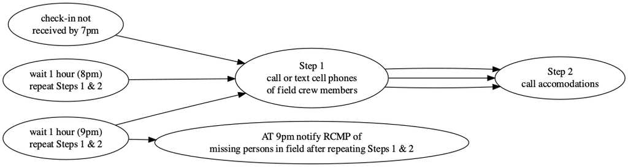

Table 2: Potential sample locations.

| id | Stream | easting | northing | comments |
| --- | --- | --- | --- | --- |
| 1004603432 | Trib to Cadorna | 639196 | 5591178 | unlikely to exist |
| 1004605514 (197844) | Trib to Bighorn | 657920 | 5452802 | 8.8% avg gradient but decent habitat upstream, Bighorn important WCT stream. Partial dewatering downstream. |
| 1004605937 (197783) | Trib to Wigwam | 662247 | 5431294 | Not on shortlist, low quality habitat: dry with poorly defined channel downstream but Wigwam important WCT stream |
| 1004606347 (197793) | Bean | 650415 | 5463819 | Large, dry channel, no fish records, abundant pools upstream of xing |
| 1024735443 | Abruzzi | 638867 | 5591423 | unlikely to exist |

# References

Fish Passage Technical Working Group. 2011. “A Checklist for Fish Habitat Confirmation Prior to the Rehabilitation Fo a Stream Crossing.” https://www2.gov.bc.ca/assets/gov/environment/natural-resource-stewardship/land-based-investment/forests-for-tomorrow/checklist-for-fish-habitat-confirmation-201112.pdf.

McPhail, J. D., and R Carveth. 1993. “Field Key to the Freshwater Fishes of British Columbia.” https://www2.gov.bc.ca/assets/gov/environment/natural-resource-stewardship/nr-laws-policy/risc/field_key_to_freshwater_fishes_of_bc_field_size_water_resistant_version.pdf.

MoE. 2011. “Field Assessment for Determining Fish Passage Status of Closed Bottom Structures.” BC Ministry of Environment (MoE). https://www2.gov.bc.ca/assets/gov/environment/natural-resource-stewardship/land-based-investment/forests-for-tomorrow/field-assessment-for-determining-fish-passage-status-of-cbs.pdf.